# Homework 1

Lusine Zilfimian

23 Feb, 2020

# Requirements

**File format:** *For this Homework, you are required to submit both R Markdown and **HTML** files with your answers and codes in it. Make sure that Rmd file works, so that there won’t be any errors when it is run and represent the same information as HTML. Under each question (not in comments) write the code along with your interpretations. Be sure to put your name at the top of your assignment (in the YAML header in front of the author).*

**Due date:** **01.03.2020 23:55**. No late homework will be accepted.

**Submission:** *You need to upload/create files in **private** [GitHub repository](https://help.github.com/en/articles/create-a-repo) and [share](https://help.github.com/en/articles/inviting-collaborators-to-a-personal-repository) with [me](https://github.com/Zilfimian). Then, add the link to your HW in the ReadMe.md file or share on Slack.*

**Rule of thumb:** *If the number of data points is greater than 50, do not print the whole data. Use subsets. Try to show all outputs (do not just store an object as a variable). Also, try to avoid using the same name for variables in the file.*

**Cheating:** *The purpose of tasks is to check your knowledge (rather than the ability of thinking). Please, try to solve tasks without googling **every** exercise. Try not to discuss HW with your classmates and work only on your file. Any similarities, which can be considered as cheated, will not be graded.*

**Good luck!**

Use `surveydata.csv` dataset uploaded on [GitHub](https://github.com/data-mining-ysu-spring-2020/Homework-Quiz) to analyze the relationship between the characteristics of respondents of the survey and conduct [a randomization](https://en.wikipedia.org/wiki/Randomized_experiment) check ( to verify whether there are some differences between [treatment and control groups](https://en.wikipedia.org/wiki/Treatment_and_control_groups)). The description of the variables and survey are given with a separate file. **Note:** Keep the order of sub-tasks.

# Task 1 (30 points): Data Cleaning

1. Import the file into R. Detect *missing values* and convert them to NAs. There are 4 types of missing values. Comment on your findings of types of missing values.
2. How many missing values are in the data?
3. Two of the variables consist of *inconsistent values*. Detect them using the function `table()`. Solve the problem without losing the information.
4. Check whether the data types are correct, if not make appropriate corrections assigning labels to each level according to the data description. For checking, use the function `sapply()`.
5. Create **two** variables of age using dates of surveys.
6. There are two variables (apart from age) that provide the same information, drop one of them. Get rid of variables that are *irrelevant* for visualization and/or variables that are not provided in the data description. Drop NAs.[^1]
7. Show and describe the structure and dimension of the data. Classify variables as qualitative (nominal or ordinal) or quantitative (interval or ratio).

## Solution 1

# Task 2 (30 points): Summary Statistics

1. Create a function that takes the *categorical* variable as an argument and returns a table with the number and percentage of each category (e.g. males and females) in each group of treatment status. Use the function `group_by()` and pipe operators. The columns of the final table will be:
- Treatment Type
- *Categorical Variable Name*
- Number of observations
- Percentage
2. Create a function that takes a numeric variable as an argument and returns the table with the mean and standard deviation of argument grouped by treatment status. Use the function `group_by()` and pipe operators. The columns of the final table will be:[^2]
- Treatment Type
- Mean
- Standart deviation

Yes, okay, I know, this is not the R programming HW. But these functions will make our life easy, so try to answer the following questions (or to solve them).

3. Show the mean and variability of `spendings` by groups. Show the number of observations grouped by gender and treatment type. Then show the number of observations grouped by another categorical variable (choose your own) and treatment type. [^3]
4. Make meaningful conclusions in sence of randomization.

## Solution 2

# Task 3 (30 points): Data Visualization

1. Describe one *numeric* variable and the variable treatment type (separately). Comment on it.
2. By using the dataset reproduce the following graph:

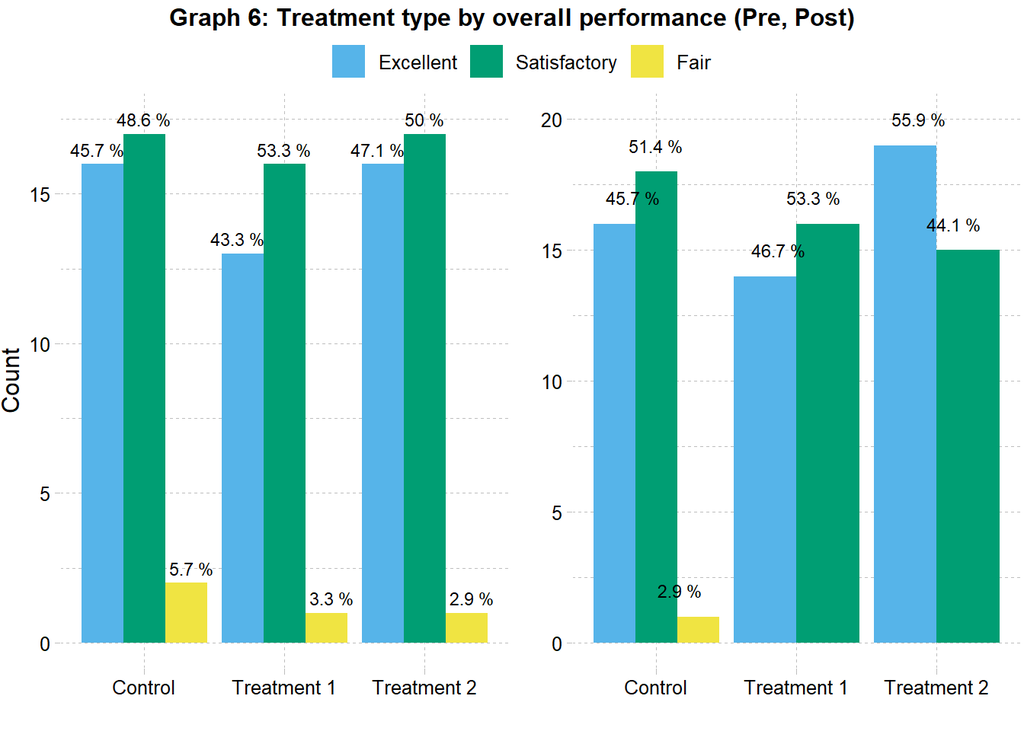

Hint: use the function from 2a. Pay attention to

- Titles (one title for two graphs) and labels
- Legends (one legend)
- Theme and style (gdocs).
- Percentages.
3. Consider grouped graphical comparisons for the chosen numeric variable and treatment type. Comment on it.
4. Make meaningful conclusions based on b and c (remember about the randomization).
5. Find the pattern between **savings** and income, use three variables (third must be categorical). Comment on it.
6. (Confirm your findings) Compute the correlation between the variables, visualize correlation by using the package `ggcorrplot`. Does any type of relationship exist among variables if the Pearson correlation coefficient is near 0?
7. Approve or reject (using the appropriate visualization):

*“After both seminars and video education, the number of answers is noticeable increases in all groups.”*

## Solution 3

# Questions (10 points)

1. What is the difference between ratio and interval variables?
2. Can we rely only on summary statistics in analyzing the data? Why?
3. Can we use the bar plot to describe the numeric variable? Why? Which kind of visualization can be used for numeric data? What about the relationship between 2 numeric variables?
4. How much time did it take you to accomplish the HW?
[^1]: You can use functionality from `dplyr` with pipelines to solve this task.
[^2]: I solved both of tasks using the function `enquo()` (find a better solution if you can.)
[^3]: You can use the function `kable()` if the style of tables annoyed you.